# REBRESION LINEAL MULTIPLE

Wilson G

2 de agosto de 2015

### Introducción

El presente documento tiene como objetivo presentar la forma de como generar un **reporte** automático del modelo de regresion multiple.

### Descripción información

Iniciamos cargando las dos bases de datos que se nos ha dado,para luego unir estas dos bases en una sola data con el comando __merge_, llamada poblacion, y eliminamos la primera columna que es el identificador, para quedarnos con los datos que seran analizados.

```r
options(warn=-1)
library(readxl)
library(ggplot2)
data1 <- read_excel("poblacion1.xlsx",sheet=1,na="")
data2 <- read_excel("poblacion2.xlsx",sheet=1,na="")

poblacion <- merge(x = data1 ,y = data2, by = "identificador", suffixes = c("",""))
poblacion <- poblacion[,-1]
```

Nuestra data queda de la siguiente manera

```r
library(DT)
datatable(poblacion)
```

|  | poblacion | var.pobl.mayor | menores.18 | part.almz.escl | var.ingresos | tasa.crimen | var.tasa.crimen | region | serv.bas.compl |
| --- | --- | --- | --- | --- | --- | --- | --- | --- | --- |
| 1 | 18.7 | 6.2 | 39.7 | 55.8 | 28.7 | 52.6 | -2.9 | A | SI |
| 2 | 13.8 | 7.2 | 10.4 | 57.9 | 26.2 | 111 | -22.6 | A | SI |
| 3 | 13.4 | 7.1 | 20.4 | 13.9 | 22.5 | 38.3 | -33.6 | A | NO |
| 4 | 11.4 | 2.6 | 38.7 | 78.2 | 18.4 | 86.6 | -12.8 | A | NO |
| 5 | 10.5 | 2.8 | 36.4 | 72.3 | 26 | 77.5 | -21.6 | A | SI |
| 6 | 10.3 | 1.4 | 29.8 | 43.7 | 29.4 | 54 | -10 | A | NO |
| 7 | 10.3 | -0.5 | 31.8 | 57.2 | 27.2 | 61.2 | -17.6 | A | NO |
| 8 | 10.3 | 3 | 31.1 | 51.7 | 26.2 | 42.4 | -31.9 | A | NO |
| 9 | 10.3 | -1.9 | 15.9 | 39.9 | 38.5 | 86.4 | -13.5 | A | SI |
| 10 | 9.4 | -1.5 | 22.4 | 22.2 | 33.5 | 61.5 | -32.7 | A | NO |

[output cut: 30 more lines]

Ahora aplicamos los siguientes comandos para tener el modelo de regresion

```r
clase<-sapply(poblacion,class)
poblacion_reg<-poblacion[,clase=="numeric"]
regresion<-lm(poblacion~.,poblacion_reg)
```

Y vemos los resultados de esta regresion multiple

```r
summary(regresion)
```

```
##
## Call:
## lm(formula = poblacion ~ ., data = poblacion_reg)
##
## Residuals:
##     Min      1Q  Median      3Q     Max
## -5.4555 -2.7500 -0.1884  1.7262 10.3631
##
## Coefficients:
##                   Estimate Std. Error t value Pr(>|t|)
## (Intercept)      4.929e+00  3.150e+00   1.565    0.127
## var.pobl.mayor   2.960e-03  8.601e-02   0.034    0.973
## menores.18       6.088e-02  1.063e-01   0.573    0.571
## part.almz.escl   3.480e-06  3.881e-02   0.000    1.000
## var.ingresos     5.557e-02  9.734e-02   0.571    0.572
## tasa.crimen     -1.440e-02  8.959e-03  -1.607    0.117
## var.tasa.crimen -4.676e-02  4.358e-02  -1.073    0.291
##
## Residual standard error: 3.524 on 33 degrees of freedom
## Multiple R-squared:  0.1987, Adjusted R-squared:  0.05303
## F-statistic: 1.364 on 6 and 33 DF,  p-value: 0.258
```

Como podemos ver hay algunos regresores que practicamente son cero.Es por eso que tenemos que ver cuales son las variables mas representativas de nuestro modelo. Esto lo hacemos de la siguiente manera:

```
## Start:  AIC=107.07
## poblacion ~ var.pobl.mayor + menores.18 + part.almz.escl + var.ingresos +
##     tasa.crimen + var.tasa.crimen
##
##                   Df Sum of Sq    RSS    AIC
## - part.almz.escl   1     0.000 409.83 105.07
## - var.pobl.mayor   1     0.015 409.84 105.08
## - var.ingresos     1     4.047 413.88 105.47
## - menores.18       1     4.076 413.91 105.47
## - var.tasa.crimen  1    14.298 424.13 106.45
## <none>                         409.83 107.07
## - tasa.crimen      1    32.088 441.92 108.09
##
## Step:  AIC=105.07
## poblacion ~ var.pobl.mayor + menores.18 + var.ingresos + tasa.crimen +
##     var.tasa.crimen
##
##                   Df Sum of Sq    RSS    AIC
## - var.pobl.mayor   1     0.015 409.84 103.08
## - var.ingresos     1     4.337 414.17 103.50
## - menores.18       1    10.073 419.90 104.05
## - var.tasa.crimen  1    18.011 427.84 104.80
## <none>                         409.83 105.07
## - tasa.crimen      1    54.693 464.52 108.08
##
## Step:  AIC=103.08
## poblacion ~ menores.18 + var.ingresos + tasa.crimen + var.tasa.crimen
##
##                   Df Sum of Sq    RSS    AIC
## - var.ingresos     1     4.475 414.32 101.51
## - menores.18       1    10.281 420.13 102.07
## - var.tasa.crimen  1    18.848 428.69 102.87
## <none>                         409.84 103.08
## - tasa.crimen      1    68.352 478.20 107.25
##
## Step:  AIC=101.51
## poblacion ~ menores.18 + tasa.crimen + var.tasa.crimen
##
##                   Df Sum of Sq    RSS    AIC
## - menores.18       1    10.902 425.22 100.55
## - var.tasa.crimen  1    20.296 434.61 101.42
## <none>                         414.32 101.51
## - tasa.crimen      1    66.885 481.20 105.50
##
## Step:  AIC=100.55
## poblacion ~ tasa.crimen + var.tasa.crimen
##
##                   Df Sum of Sq    RSS     AIC
## - var.tasa.crimen  1    14.351 439.57  99.877
## <none>                         425.22 100.549
## - tasa.crimen      1    83.257 508.48 105.702
##
## Step:  AIC=99.88
## poblacion ~ tasa.crimen
##
##               Df Sum of Sq    RSS     AIC
## <none>                     439.57  99.877
## - tasa.crimen  1    71.895 511.47 103.936
```

```
##
## Call:
## lm(formula = poblacion ~ tasa.crimen, data = poblacion_reg)
##
## Coefficients:
## (Intercept)  tasa.crimen
##     8.61700     -0.01247
```

Como podemos ver nuestro modelo se redujo a un modelo de regresion simple. Es este caso la variable **tasa.crimen** es la mas representativa, quedando nuestro modelo de la siguiente manera:

$\hat{pobl} = 8.6170024 + (-0.0124691) \hat{tasa.cr}$

### Interpretación

**Interpretación modelo:** _Si tasa.crimen se incrementa en una unidad, entonces poblacion disminuye en promedio -0.0124691

**Interpretación $R^2$:** *El modelo de regresión lineal obtenido explica el 14.0566909350585 % de la variabilidad total.*

### Intervalos de confianza

```r
confint(regre,level = 0.95)
```

```
##                   2.5 %      97.5 %
## (Intercept)  7.05204569 10.18195920
## tasa.crimen -0.02259422 -0.00234391
```

Como podemos veren amnos casos, al 95% de confianza los valores son distintos de cero por lo tanto se rechaza la hipotesis inicial.

### Gráficos residuales

```r
residuo <- regre[["residuals"]]
prediccion <- regre[["fitted.values"]]
data<- data.frame(poblacion[,"poblacion"],poblacion[,"tasa.crimen"], prediccion,residuo)
datatable(data,filter="top", options = list(
  searching = TRUE,
  pageLength = 5,
 lengthMenu = c(5, 10, 15)
 ))
```

|  | poblacion....poblacion.. | poblacion....tasa.crimen.. | prediccion | residuo |
| --- | --- | --- | --- | --- |
| 1 | 18.7 | 52.6 | 7.96112971584769 | 10.7388702841523 |
| 2 | 13.8 | 111 | 7.23293641721664 | 6.56706358278336 |
| 3 | 13.4 | 38.3 | 8.13943732150563 | 5.26056267849437 |
| 4 | 11.4 | 86.6 | 7.53718156253509 | 3.86281843746491 |
| 5 | 10.5 | 77.5 | 7.65065003886288 | 2.84934996113712 |
| 6 | 10.3 | 54 | 7.94367302718187 | 2.35632697281813 |
| 7 | 10.3 | 61.2 | 7.85389577118626 | 2.44610422881374 |
| 8 | 10.3 | 42.4 | 8.08831416184146 | 2.21168583815854 |
| 9 | 10.3 | 86.4 | 7.53967537520164 | 2.76032462479836 |
| 10 | 9.4 | 61.5 | 7.85015505218645 | 1.54984494781355 |

[output cut: 30 more lines]

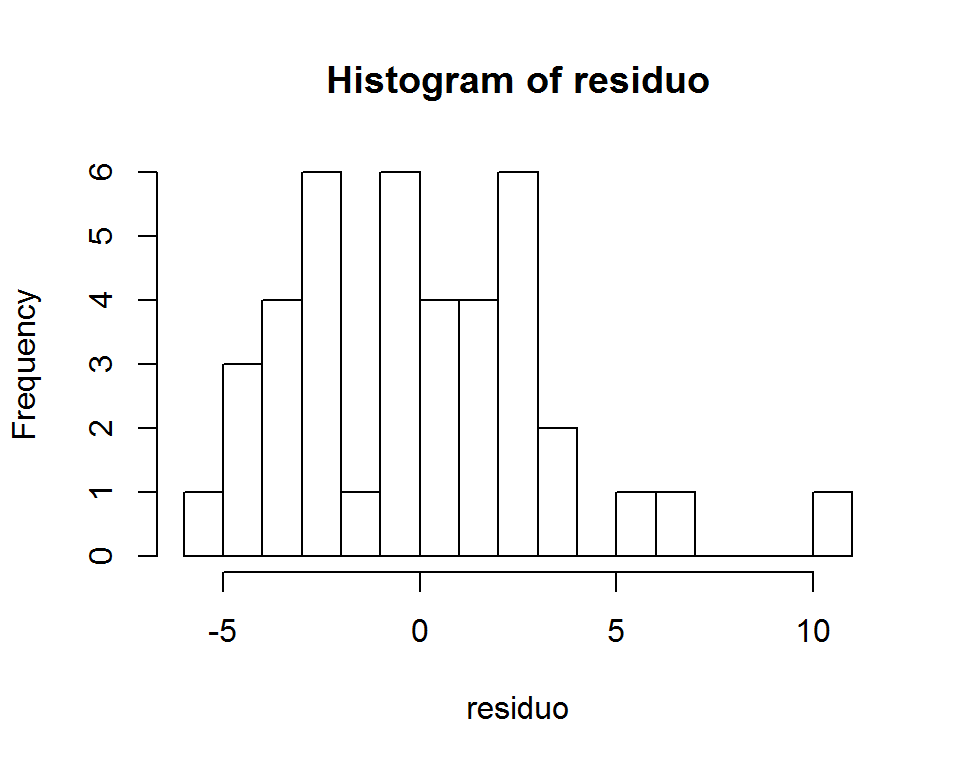

```r
hist(residuo,15)
```

```r
mean(residuo)
```

```
## [1] 4.428153e-17
```

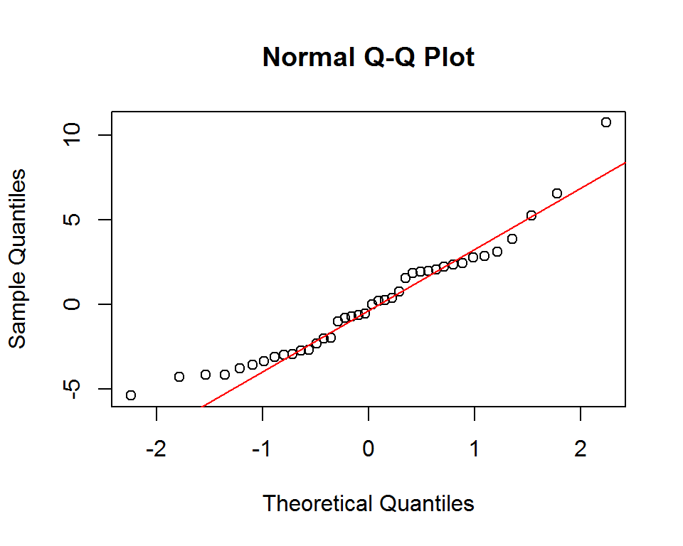

```r
qqnorm(residuo)
qqline(residuo,col="red")
```

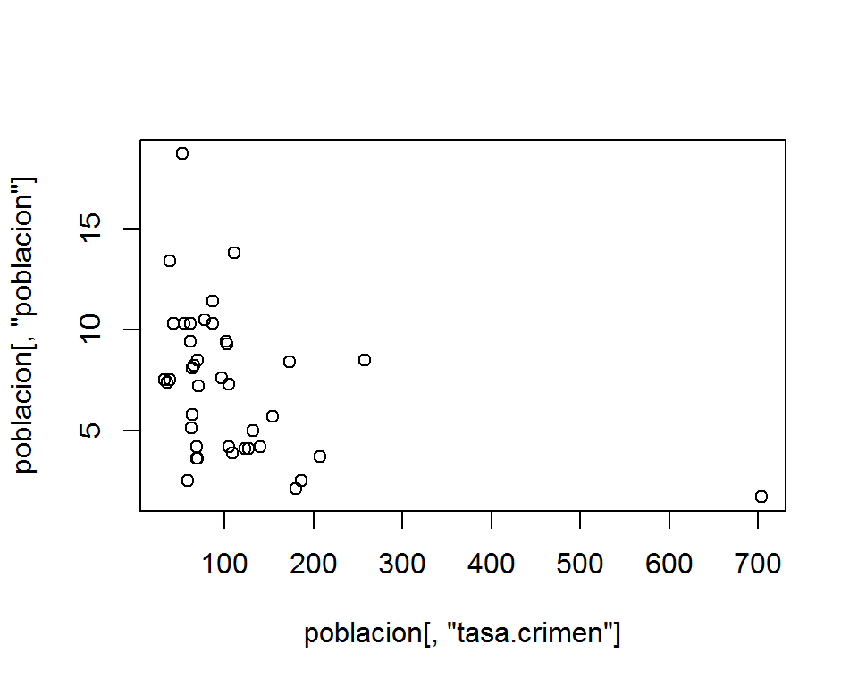

```r
plot(poblacion[,"tasa.crimen"],poblacion[,"poblacion"])
```

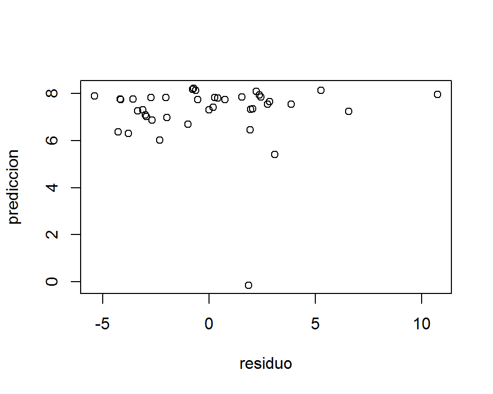

```r
plot(residuo,prediccion)
```

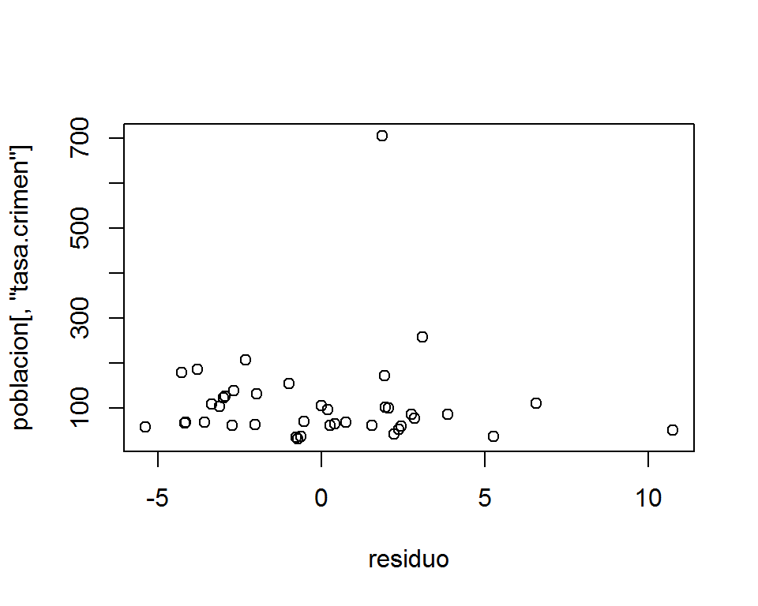

```r
plot(residuo,poblacion[,"tasa.crimen"])
```

### CONCLUSIONES

1. El modelo de regresion multiple puede ser reducido a uno de regresion simple utilizando la variable **tasa.crimen** como unico regresor y omitiendo los demas ya que no aportan mucho.
2. Pudimos darnos cuentas que en la regresion multiple la mayoria de regresores era casi cero y es por eso que el modelo se redujo a un modelo simple
3. Se determino que una vez hecho el modelo reducido, las hipotesis nula para el intercepto y para el regresos, son rechazas, es decir se acptaron que estos son distintos a cero.
4. Se necesitaran de mas observaciones para tener un modelo, ya que con los 40 datos no fueron suficientes para encontrara un buen modelo.
5. En la media de los residuos nos dio un valor 4.428153e-17 , lo cual cumple nuestras hipotesis N.
6. En la gráfica de residuos estos puntos estan dentro de una franja , por lo cual no vulnera ninguna de nuestras hipótesis.